# KNN

Sean Schilk

10/31/2025

## Question 1 Read in data set called HW6data.csv. This includes 1,267 observations and 229 variables. The response variable is called Solubility. The rest are potential predictors. Any variable that starts with an FP means it’s a binary “fingerprint” (0/1) that is associated with the presence or absence of a particular chemical structure. The other variables are characteristics of the sampled molecule. NOTE: Unless stated otherwise, use 10-fold CV and type set.seed(1) before you use EACH train( ) function. This is to make sure we get the same results and we can compare across models. ALSO, do NOT print the structure of the data set or look at the summaries unless explicitly stated to do so. Otherwise, you final Word document is going to look pretty nasty.

The `message = FALSE` in the .Rmd file prevents the final document from printing the messages you normally see when you install packages.

```r
setwd("~/STA419/REDO/8.KNN")

library(caret)
library(tidyverse)

soluble <- read.csv("HW6data.csv")
```

#### Question (a) - (b) Use OLS to fit the linear model with all of the remaining (not including Solubility) variables as predictors. What was your estimate of the test RMSE? Interpret this value. Note: The warning message you receive is because some of the variables are perfectly correlated with one another

```r
fitControl <- trainControl(method = "cv", number = 10)
set.seed(1)
model.lm <- train(Solubility ~ .,
                  method = "lm",
                  data = soluble,
                  trControl = fitControl)

model.lm
```

```
## Linear Regression
##
## 1267 samples
##  228 predictor
##
## No pre-processing
## Resampling: Cross-Validated (10 fold)
## Summary of sample sizes: 1141, 1140, 1140, 1139, 1141, 1141, ...
## Resampling results:
##
##   RMSE       Rsquared   MAE
##   0.7126272  0.8800056  0.5329865
##
## Tuning parameter 'intercept' was held constant at a value of TRUE
```

Using OLS regression and all the predictors, we get a test RMSE of 0.713. This means that our predicted values of the held out test observations are off by an average of 0.713 units.

# Use KNN with k = 1, 3, 5, 7, 9, . . . , 21. What was your estimate of the test RMSE? Explain why you think we did worse with KNN than we did using OLS regression

```r
kGrid <- expand.grid(k = seq(1, 21, by = 2))

set.seed(1)
model.knn <- train(Solubility ~ .,
                   data = soluble,
                   method = "knn",
                   trControl = fitControl,
                   tuneGrid = kGrid)
#                   preProc = c("center", "scale"))

model.knn
```

```
## k-Nearest Neighbors
##
## 1267 samples
##  228 predictor
##
## No pre-processing
## Resampling: Cross-Validated (10 fold)
## Summary of sample sizes: 1141, 1140, 1140, 1139, 1141, 1141, ...
## Resampling results across tuning parameters:
##
##   k   RMSE       Rsquared   MAE
##    1  0.9815064  0.7778647  0.6736255
##    3  0.8949325  0.8094420  0.6291194
##    5  0.8849426  0.8130053  0.6313039
##    7  0.8896187  0.8108155  0.6445653
##    9  0.8841993  0.8122641  0.6500654
##   11  0.8996576  0.8063471  0.6634821
##   13  0.9108335  0.8026873  0.6769500
##   15  0.9218187  0.7982533  0.6870723
##   17  0.9314113  0.7943457  0.6922521
##   19  0.9318402  0.7942789  0.6931103
##   21  0.9339201  0.7934098  0.6990959
##
## RMSE was used to select the optimal model using the smallest value.
## The final value used for the model was k = 9.
```

The optimal value of k is 9. With this value we get a test RMSE of 0.884. This is worst than what we got using OLS regression. This can happen for a number of reasons. One is that there is truly a linear relationship between the predictors and the response. Alternatively, KNN tends to do worse in higher dimensions because neighbors are “further” away from one another.

#### (c) Let’s look at a histogram of the coefficient estimates. Suppose you called the object containing your output from the previous step model.lm, then type: hist(summary(model.lm)$coefficient What can you say about the majority of the coefficient estimates?

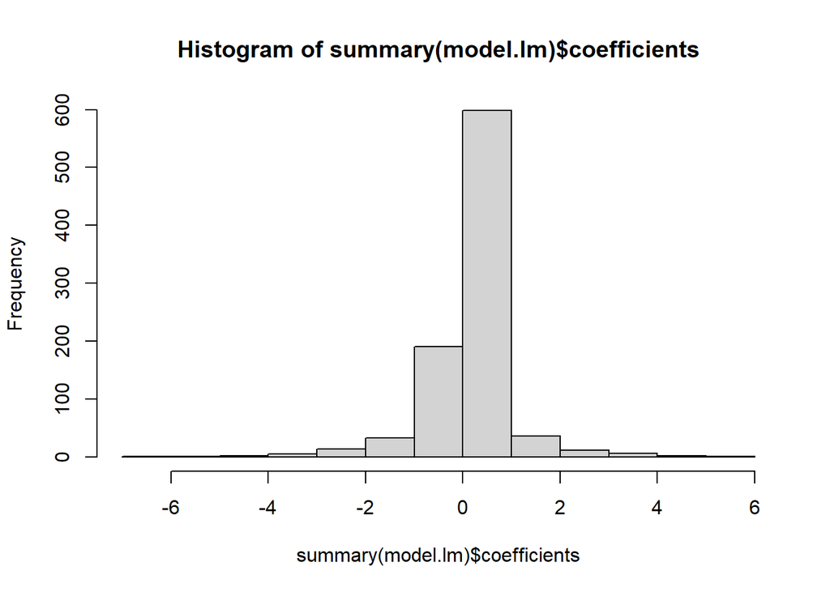

```r
hist(summary(model.lm)$coefficients)
```

From the histogram of the estimated coefficients, we can see that the vast majority are near zero. This mostly likely means we can remove some predictors or shrink their estimates even closer to zero in order to remove some of the variance from our model.

#### (d) - (f) Now, let’s use backward stepwise regression to see if removing some of the predictors (after fitting) does better. There are 228 potential predictors. However, let’s stop at 150 potential predictors. So tune your grid to go from 1 to 150. What was the optimal number of predictors to use based on 10-fold CV? What was the estimate of the test RMSE? Explain why you think we did better with fewer predictors in the final model. NOTE: You will most likely see something like “Reordering variables…” This is due to the same issue as before (perfectly correlated variables).

```r
nvmaxGrid <- expand.grid(nvmax = seq(1,
                                     150, by = 1))

set.seed(1)
model.step <- train(Solubility ~ .,
                      data = soluble,
                      method = "leapBackward",
                      trControl = fitControl,
                      tuneGrid = nvmaxGrid)
```

[output not shown]

[output not shown]

[output not shown]

[output not shown]

[output not shown]

[output not shown]

[output not shown]

[output not shown]

[output not shown]

[output not shown]

[output not shown]

```r
model.step
```

```
## Linear Regression with Backwards Selection
##
## 1267 samples
##  228 predictor
##
## No pre-processing
## Resampling: Cross-Validated (10 fold)
## Summary of sample sizes: 1141, 1140, 1140, 1139, 1141, 1141, ...
## Resampling results across tuning parameters:
##
##   nvmax  RMSE       Rsquared   MAE
##     1    1.6527876  0.3580643  1.2569457
##     2    1.4625823  0.4953717  1.1141102
##     3    1.3996662  0.5368409  1.0806414
##     4    1.3583745  0.5617511  1.0641508
```

[output cut: 149 more lines]

Using backward stepwise regression, we get the optimal number of predictors to be 117. This gives us a test RMSE of 0.710, which is slightly better than the full model.

# Use ggplot( ) to look at the number of variables in the model on the x-axis and the test RMSE on the y-axis. What do you notice? Often, instead of using the absolute minimum value of the RMSE, we look for the elbow in the plot. This occurs at the point where the “curve” stops decreasing at the same rate and starts to level off. At approximately which value of nvmax do you start to see an elbow?

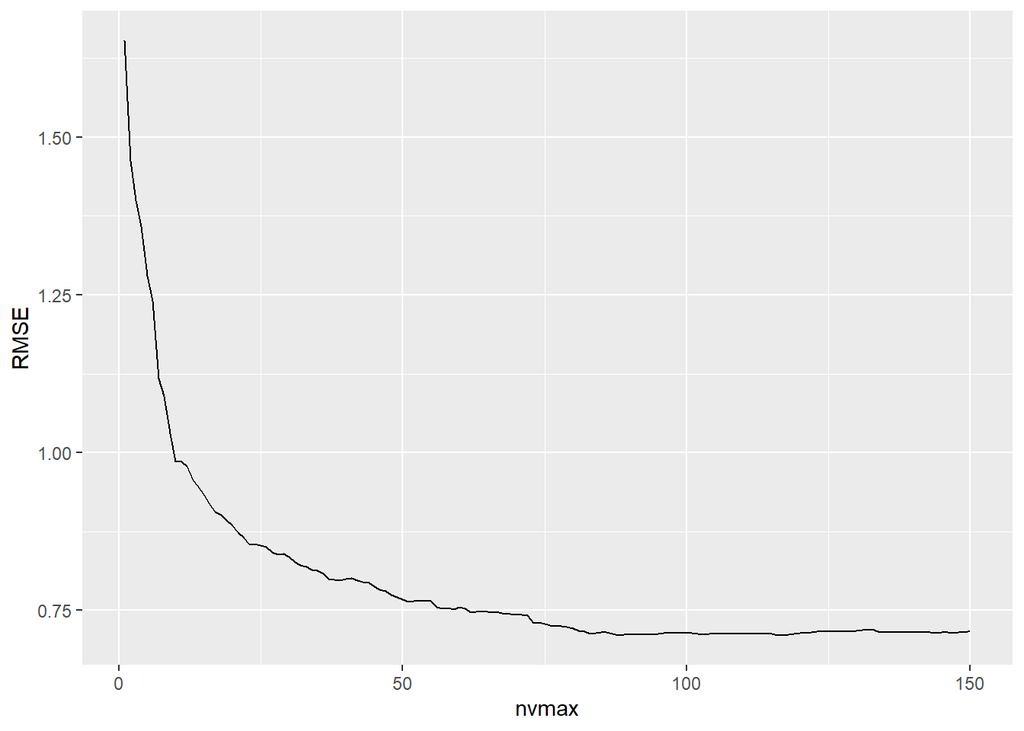

```r
  ggplot(model.step$results, aes(x = nvmax, y = RMSE)) +
    geom_line()
```

# Let’s use BIC scores instead of the test RMSE to decide on the number of predictors in the final model. Assuming you called you model from (c) model.step, type: which.min(summary(model.step What did you get? Is it more or less than the number of predictors we got with the test RMSE?

Using BIC scores, which put a penalty on the number of predictors in the model after the model is fit (instead of using test RMSE values from CV), we get an optimal number of parameters to be 59. It is pretty common to have BIC scores give a more parsimonious model than other methods.

```r
which.min(summary(model.step)$bic)
```

```
## [1] 59
```

#### (g) - (h) Now, let’s use ridge regression instead. Set your grid of lambda tuning parameters to be: 10^seq(-3, .5, length = 100). What was your optimal lambda? What was the test RMSE for this lambda? Note: you should center and scale your variables before fitting penalized models!

```r
tune.grid <- expand.grid(alpha = 0,
                           lambda = 10^seq(-4, .5, length = 100))

set.seed(1)
model.ridge <- train(Solubility ~ .,
                    data = soluble,
                    method = "glmnet",
                    trControl = fitControl,
                    tuneGrid = tune.grid,
                    preProcess = c("center","scale"))

model.ridge
```

```
## glmnet
##
## 1267 samples
##  228 predictor
##
## Pre-processing: centered (228), scaled (228)
## Resampling: Cross-Validated (10 fold)
## Summary of sample sizes: 1141, 1140, 1140, 1139, 1141, 1141, ...
## Resampling results across tuning parameters:
##
##   lambda        RMSE       Rsquared   MAE
##   0.0001000000  0.6704221  0.8924728  0.5138610
##   0.0001110336  0.6704221  0.8924728  0.5138610
##   0.0001232847  0.6704221  0.8924728  0.5138610
##   0.0001368875  0.6704221  0.8924728  0.5138610
##   0.0001519911  0.6704221  0.8924728  0.5138610
##   0.0001687612  0.6704221  0.8924728  0.5138610
##   0.0001873817  0.6704221  0.8924728  0.5138610
##   0.0002080568  0.6704221  0.8924728  0.5138610
##   0.0002310130  0.6704221  0.8924728  0.5138610
##   0.0002565021  0.6704221  0.8924728  0.5138610
##   0.0002848036  0.6704221  0.8924728  0.5138610
##   0.0003162278  0.6704221  0.8924728  0.5138610
##   0.0003511192  0.6704221  0.8924728  0.5138610
##   0.0003898604  0.6704221  0.8924728  0.5138610
##   0.0004328761  0.6704221  0.8924728  0.5138610
##   0.0004806381  0.6704221  0.8924728  0.5138610
##   0.0005336699  0.6704221  0.8924728  0.5138610
##   0.0005925531  0.6704221  0.8924728  0.5138610
##   0.0006579332  0.6704221  0.8924728  0.5138610
##   0.0007305272  0.6704221  0.8924728  0.5138610
##   0.0008111308  0.6704221  0.8924728  0.5138610
##   0.0009006280  0.6704221  0.8924728  0.5138610
##   0.0010000000  0.6704221  0.8924728  0.5138610
##   0.0011103363  0.6704221  0.8924728  0.5138610
##   0.0012328467  0.6704221  0.8924728  0.5138610
##   0.0013688745  0.6704221  0.8924728  0.5138610
##   0.0015199111  0.6704221  0.8924728  0.5138610
##   0.0016876125  0.6704221  0.8924728  0.5138610
##   0.0018738174  0.6704221  0.8924728  0.5138610
```

[output cut: 60 more lines]

```
##   1.1103363182  0.7590236  0.8695352  0.5910350
##   1.2328467394  0.7680465  0.8673088  0.5983995
##   1.3688745095  0.7776521  0.8649477  0.6061924
##   1.5199110830  0.7879216  0.8624318  0.6146552
##   1.6876124758  0.7988689  0.8597917  0.6235901
##   1.8738174229  0.8105396  0.8570035  0.6332901
##   2.0805675382  0.8229727  0.8540592  0.6437719
##   2.3101297001  0.8362001  0.8509546  0.6549593
##   2.5650209057  0.8502426  0.8476886  0.6666750
##   2.8480358684  0.8651242  0.8442627  0.6787986
##   3.1622776602  0.8808827  0.8406724  0.6914448
##
## Tuning parameter 'alpha' was held constant at a value of 0
## RMSE was used to select the optimal model using the smallest value.
## The final values used for the model were alpha = 0 and lambda = 0.1232847.
```

# Assuming you called your output from the previous part model.ridge, type: coef.ridge <- coef(model.ridge$finalModel, model.ridge$bestTune$lambda). Look at the histogram of the ridge regression coefficients by typing: hist(coef.ridge[,1]). Compare this histogram to the one you got from part (b). What do you notice? Type: length(which(coef.ridge[,1] == 0)). This is the number of coefficients that were set to exactly 0. How many did you get?

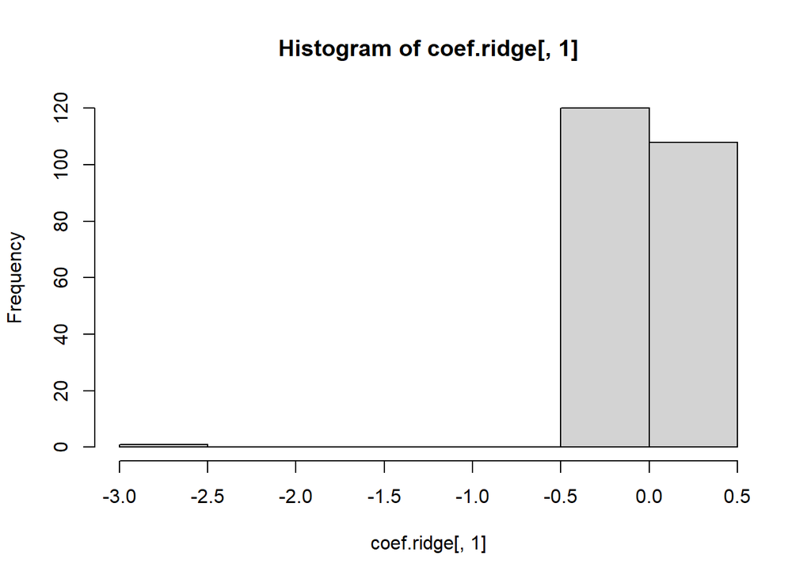

```r
coef.ridge <- coef(model.ridge$finalModel,
                   model.ridge$bestTune$lambda)

hist(coef.ridge[,1])
```

```r
length(which(coef.ridge[,1] == 0))
```

```
## [1] 0
```

We can see from the histogram that almost all of the estimated coefficients are now near zero. However, ridge regression will never set any of them to be exactly zero.

#### (i) Repeat the previous two parts using the LASSO instead. Use the same grid of tuning parameters

The LASSO finds $\lambda = 0.0043$ to be optimal, which results in a test RMSE of 0.663, which is slightly better than the ridge model. We can also see that the LASSO, unlike the ridge model, sets 78 of estimated coefficients to be exactly zero. This means we would keep 150 of the predictors in the final model. The LASSO simultaneously fits the model and perform variable selection.

```r
tune.grid <- expand.grid(alpha = 1,
                         lambda = 10^seq(-4, .5, length = 100))

set.seed(1)
model.lasso <- train(Solubility ~ .,
                     data = soluble,
                     method = "glmnet",
                     trControl = fitControl,
                     tuneGrid = tune.grid,
                     preProcess = c("center","scale"))
model.lasso
```

```
## glmnet
##
## 1267 samples
##  228 predictor
##
## Pre-processing: centered (228), scaled (228)
## Resampling: Cross-Validated (10 fold)
## Summary of sample sizes: 1141, 1140, 1140, 1139, 1141, 1141, ...
## Resampling results across tuning parameters:
##
##   lambda        RMSE       Rsquared   MAE
##   0.0001000000  0.6959844  0.8850339  0.5223631
##   0.0001110336  0.6959844  0.8850339  0.5223631
##   0.0001232847  0.6959844  0.8850339  0.5223631
##   0.0001368875  0.6959844  0.8850339  0.5223631
##   0.0001519911  0.6959844  0.8850339  0.5223631
##   0.0001687612  0.6959844  0.8850339  0.5223631
##   0.0001873817  0.6959841  0.8850340  0.5223630
##   0.0002080568  0.6959678  0.8850383  0.5223559
##   0.0002310130  0.6958885  0.8850599  0.5223199
##   0.0002565021  0.6957447  0.8851022  0.5222200
##   0.0002848036  0.6954462  0.8851946  0.5219209
##   0.0003162278  0.6951400  0.8852822  0.5216519
##   0.0003511192  0.6947598  0.8853927  0.5213066
##   0.0003898604  0.6938183  0.8856801  0.5206417
##   0.0004328761  0.6929979  0.8859186  0.5200546
##   0.0004806381  0.6922234  0.8861356  0.5194972
##   0.0005336699  0.6906989  0.8865979  0.5186465
##   0.0005925531  0.6894340  0.8869643  0.5178354
##   0.0006579332  0.6884491  0.8872532  0.5172353
##   0.0007305272  0.6869911  0.8876735  0.5164209
##   0.0008111308  0.6852440  0.8881529  0.5153895
##   0.0009006280  0.6838199  0.8885467  0.5146125
##   0.0010000000  0.6823043  0.8889596  0.5136810
##   0.0011103363  0.6810348  0.8893046  0.5127770
##   0.0012328467  0.6798036  0.8896655  0.5121758
##   0.0013688745  0.6783523  0.8901001  0.5115172
##   0.0015199111  0.6768293  0.8905513  0.5107915
##   0.0016876125  0.6751484  0.8910379  0.5098528
##   0.0018738174  0.6736146  0.8914854  0.5089932
```

[output cut: 60 more lines]

```
##   1.1103363182  1.9278144  0.4189354  1.4952604
##   1.2328467394  2.0007565  0.4189354  1.5579129
##   1.3688745095  2.0507379        NaN  1.6026278
##   1.5199110830  2.0507379        NaN  1.6026278
##   1.6876124758  2.0507379        NaN  1.6026278
##   1.8738174229  2.0507379        NaN  1.6026278
##   2.0805675382  2.0507379        NaN  1.6026278
##   2.3101297001  2.0507379        NaN  1.6026278
##   2.5650209057  2.0507379        NaN  1.6026278
##   2.8480358684  2.0507379        NaN  1.6026278
##   3.1622776602  2.0507379        NaN  1.6026278
##
## Tuning parameter 'alpha' was held constant at a value of 1
## RMSE was used to select the optimal model using the smallest value.
## The final values used for the model were alpha = 1 and lambda = 0.004328761.
```

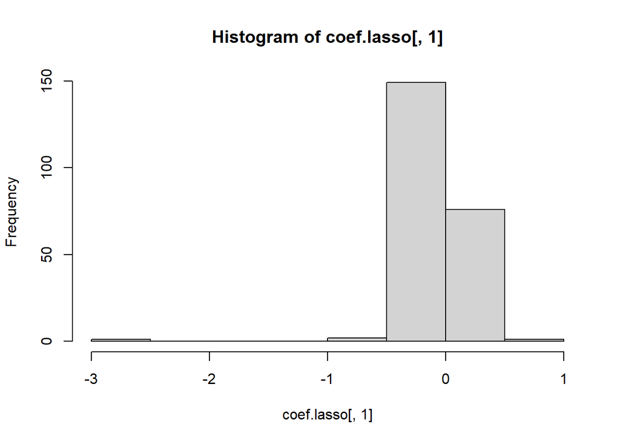

```r
coef.lasso <- coef(model.lasso$finalModel,
                   model.lasso$bestTune$lambda)
  hist(coef.lasso[,1])
```

```r
  length(which(coef.lasso[,1] == 0))
```

```
## [1] 78
```

##### (j) Which of the five models (full OLS regression, KNN, backward selection, ridge regression, and LASSO) would you choose as your final model? Explain your reasoning.

There is not a right or wrong answer here. I would argue that the LASSO model is best because not only does it give the best test RMSE, it also makes a more parsimonious model by setting some of the variable coefficients to 0.